# Análisis de Supervivencia de datos de Cáncer de Colon

# Introducción

En esta guía aprenderás a realizar un análisis de supervivencia utilizando R, con un conjunto de datos clínicos sobre cáncer de colon. Este tipo de análisis es útil para estudiar el tiempo hasta la ocurrencia de un evento (muerte), y cómo ese tiempo se relaciona con diversas características de los pacientes.

Utilizaremos funciones de los paquetes `survival` y `survminer`.

**Note**

El objetivo de esta práctica es aplicar técnicas fundamentales como Kaplan-Meier, pruebas log-rank, modelos de Cox, y verificación de supuestos.

# 1. Preparación del entorno

Instala y carga los paquetes necesarios:

```r
packages <- c("survival","survminer","dplyr","ggplot2","flexsurv")
if (length(setdiff(packages, rownames(installed.packages()))) > 0) {
  install.packages(setdiff(packages, rownames(installed.packages())), repos = "http://cran.rstudio.com")
}
sapply(packages, require, character.only=TRUE)
```

# 2. Carga de datos y exploración inicial

Se utiliza el dataset colon del paquete survival de R, que contiene información de pacientes que participaron en un estudio clínico. Se filtran los casos completos de datos cuando el evento es muerte `(etype == 2)`. Además se crea un objeto de supervivencia (Surv) ‘time’ es el tiempo de seguimiento y ‘status’ es el indicador de evento (1 = evento, 0 = censurado)

```r
data(cancer, package = "survival")
# Explorar el dataset
str(colon)
```

```
'data.frame':   1858 obs. of  16 variables:
 $ id      : num  1 1 2 2 3 3 4 4 5 5 ...
 $ study   : num  1 1 1 1 1 1 1 1 1 1 ...
 $ rx      : Factor w/ 3 levels "Obs","Lev","Lev+5FU": 3 3 3 3 1 1 3 3 1 1 ...
 $ sex     : num  1 1 1 1 0 0 0 0 1 1 ...
 $ age     : num  43 43 63 63 71 71 66 66 69 69 ...
 $ obstruct: num  0 0 0 0 0 0 1 1 0 0 ...
 $ perfor  : num  0 0 0 0 0 0 0 0 0 0 ...
 $ adhere  : num  0 0 0 0 1 1 0 0 0 0 ...
 $ nodes   : num  5 5 1 1 7 7 6 6 22 22 ...
 $ status  : num  1 1 0 0 1 1 1 1 1 1 ...
 $ differ  : num  2 2 2 2 2 2 2 2 2 2 ...
 $ extent  : num  3 3 3 3 2 2 3 3 3 3 ...
 $ surg    : num  0 0 0 0 0 0 1 1 1 1 ...
 $ node4   : num  1 1 0 0 1 1 1 1 1 1 ...
 $ time    : num  1521 968 3087 3087 963 ...
 $ etype   : num  2 1 2 1 2 1 2 1 2 1 ...
```

```r
colon_clean <- colon %>%
  filter(etype == 2) %>%
  na.omit() %>%
  mutate(surv_obj = Surv(time, status),
         sex = factor(sex,
                      levels = c(0, 1),
                      labels = c("Mujer", "Hombre")))
summary(colon_clean)
```

```
       id            study         rx          sex           age
 Min.   :  1.0   Min.   :1   Obs    :305   Mujer :428   Min.   :18.00
 1st Qu.:234.8   1st Qu.:1   Lev    :294   Hombre:460   1st Qu.:53.00
 Median :466.5   Median :1   Lev+5FU:289                Median :61.00
 Mean   :466.5   Mean   :1                              Mean   :59.81
 3rd Qu.:700.2   3rd Qu.:1                              3rd Qu.:69.00
 Max.   :929.0   Max.   :1                              Max.   :85.00
    obstruct          perfor            adhere           nodes
 Min.   :0.0000   Min.   :0.00000   Min.   :0.0000   Min.   : 0.000
 1st Qu.:0.0000   1st Qu.:0.00000   1st Qu.:0.0000   1st Qu.: 1.000
 Median :0.0000   Median :0.00000   Median :0.0000   Median : 2.000
 Mean   :0.1926   Mean   :0.03041   Mean   :0.1441   Mean   : 3.663
 3rd Qu.:0.0000   3rd Qu.:0.00000   3rd Qu.:0.0000   3rd Qu.: 5.000
 Max.   :1.0000   Max.   :1.00000   Max.   :1.0000   Max.   :33.000
     status           differ          extent           surg
 Min.   :0.0000   Min.   :1.000   Min.   :1.000   Min.   :0.000
 1st Qu.:0.0000   1st Qu.:2.000   1st Qu.:3.000   1st Qu.:0.000
 Median :0.0000   Median :2.000   Median :3.000   Median :0.000
 Mean   :0.4842   Mean   :2.062   Mean   :2.884   Mean   :0.268
 3rd Qu.:1.0000   3rd Qu.:2.000   3rd Qu.:3.000   3rd Qu.:1.000
 Max.   :1.0000   Max.   :3.000   Max.   :4.000   Max.   :1.000
     node4             time            etype
 Min.   :0.0000   Min.   :  23.0   Min.   :2
 1st Qu.:0.0000   1st Qu.: 809.8   1st Qu.:2
 Median :0.0000   Median :1983.0   Median :2
 Mean   :0.2646   Mean   :1674.8   Mean   :2
 3rd Qu.:1.0000   3rd Qu.:2378.5   3rd Qu.:2
 Max.   :1.0000   Max.   :3329.0   Max.   :2
      surv_obj.time            surv_obj.status
 Min.   :  23.0000000      Min.   :0.000000000000
 1st Qu.: 809.7500000      1st Qu.:0.000000000000
 Median :1983.0000000      Median :0.000000000000
 Mean   :1674.7545045      Mean   :0.484234234234
 3rd Qu.:2378.5000000      3rd Qu.:1.000000000000
 Max.   :3329.0000000      Max.   :1.000000000000
```

```r
head(colon_clean)
```

```
   id study      rx    sex age obstruct perfor adhere nodes status differ
1   1     1 Lev+5FU Hombre  43        0      0      0     5      1      2
3   2     1 Lev+5FU Hombre  63        0      0      0     1      0      2
5   3     1     Obs  Mujer  71        0      0      1     7      1      2
7   4     1 Lev+5FU  Mujer  66        1      0      0     6      1      2
9   5     1     Obs Hombre  69        0      0      0    22      1      2
11  6     1 Lev+5FU  Mujer  57        0      0      0     9      1      2
   extent surg node4 time etype surv_obj
1       3    0     1 1521     2     1521
3       3    0     0 3087     2    3087+
5       2    0     1  963     2      963
7       3    1     1  293     2      293
9       3    1     1  659     2      659
11      3    0     1 1767     2     1767
```

# 3. Estimador de Kaplan-Meier

Se utiliza el estimador de Kaplan-Meier (survfit) para:

- Estimar la probabilidad de supervivencia a lo largo del tiempo.
- Visualizar la curva de supervivencia general y por grupos
- Para los casos cuando se estima por grupo se imprime el p-valor del log-rank test

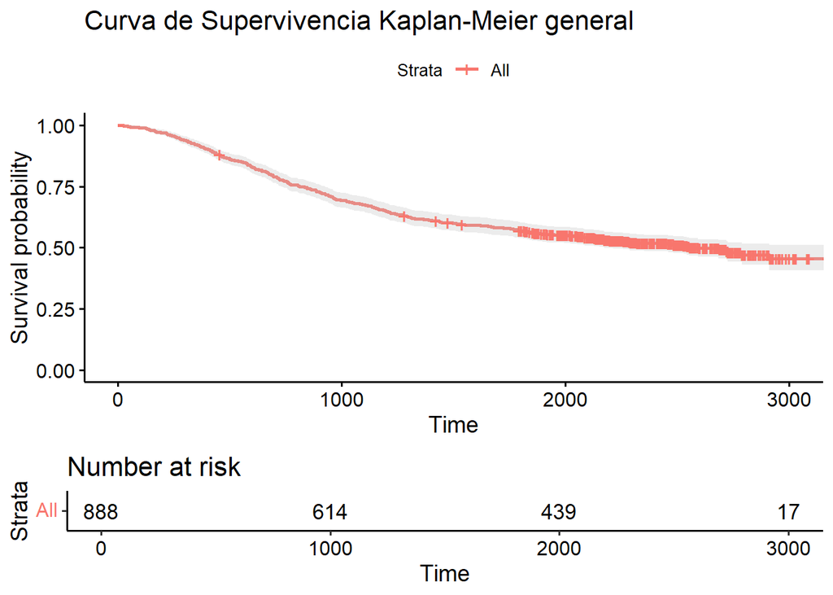

```r
# Ajustar el modelo Kaplan-Meier por una variable (ej. sexo)
fit_km <- survfit(surv_obj ~ 1, data = colon_clean)

# Visualizar la curva de Kaplan-Meier
ggsurvplot(fit_km,
           conf.int = TRUE, # Mostrar intervalos de confianza
           risk.table = TRUE, # Mostrar tabla de riesgo
           title = "Curva de Supervivencia Kaplan-Meier general")
```

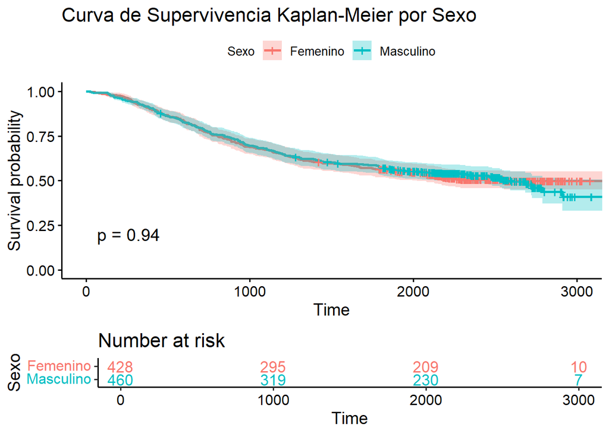

```r
# Ajustar el modelo Kaplan-Meier por una variable (ej. sexo)
fit_km_sex <- survfit(surv_obj ~ sex, data = colon_clean)

# Visualizar la curva de Kaplan-Meier
ggsurvplot(fit_km_sex,
           pval = TRUE, # Mostrar p-valor del log-rank test
           conf.int = TRUE, # Mostrar intervalos de confianza
           risk.table = TRUE, # Mostrar tabla de riesgo
           risk.table.col = "strata",
           legend.title = "Sexo",
           legend.labs = c("Femenino", "Masculino"),
           title = "Curva de Supervivencia Kaplan-Meier por Sexo")
```

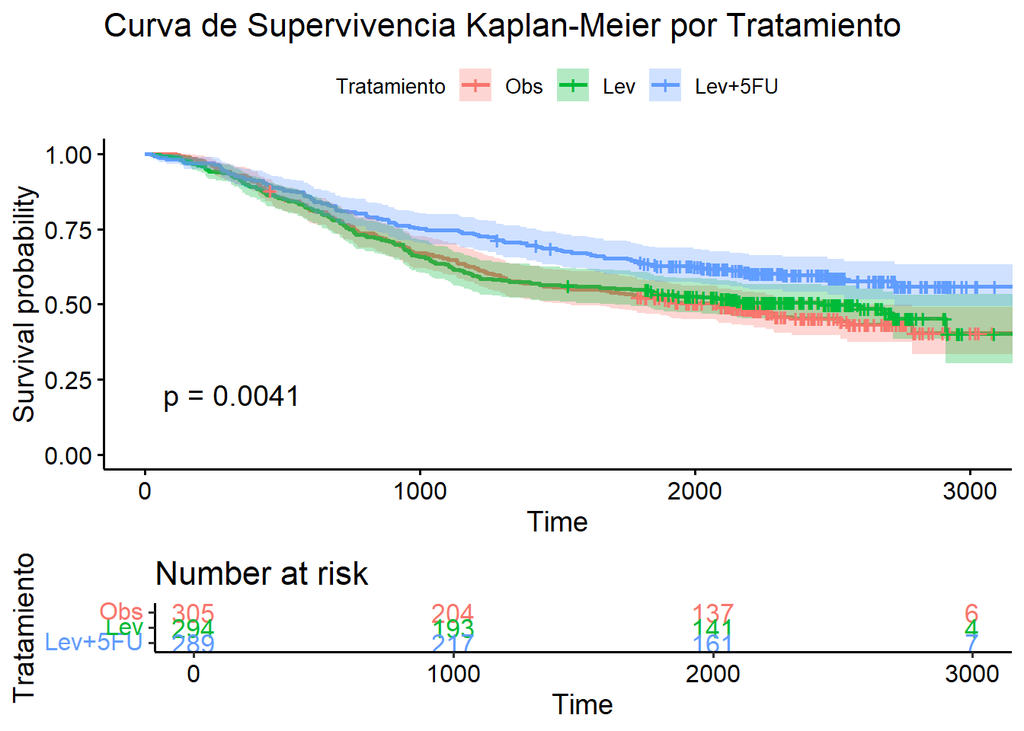

```r
# Ajustar el modelo Kaplan-Meier por otra variable (ej. tratamiento: rx)
fit_km_rx <- survfit(surv_obj ~ rx, data = colon_clean)

ggsurvplot(fit_km_rx,
           pval = TRUE,
           conf.int = TRUE,
           risk.table = TRUE,
           risk.table.col = "strata",
           legend.title = "Tratamiento",
           legend.labs = c("Obs", "Lev", "Lev+5FU"),
           title = "Curva de Supervivencia Kaplan-Meier por Tratamiento")
```

# 4. Comparación entre grupos

Se realiza la prueba log-rank `(survdiff)` para comparar la supervivencia entre distintos tratamientos, evaluando si las diferencias son estadísticamente significativas.

```r
survdiff(Surv(time, status) ~ sex, data = colon_clean)
```

```
Call:
survdiff(formula = Surv(time, status) ~ sex, data = colon_clean)

             N Observed Expected (O-E)^2/E (O-E)^2/V
sex=Mujer  428      208      207   0.00336   0.00649
sex=Hombre 460      222      223   0.00312   0.00649

 Chisq= 0  on 1 degrees of freedom, p= 0.9
```

**Interpretación**

- No hay evidencia estadística de diferencia en la supervivencia entre hombres y mujeres.
- El valor p = 0.9 es mucho mayor que 0.05 → no se rechaza la hipótesis nula.

```r
survdiff(Surv(time, status) ~ rx, data = colon_clean)
```

```
Call:
survdiff(formula = Surv(time, status) ~ rx, data = colon_clean)

             N Observed Expected (O-E)^2/E (O-E)^2/V
rx=Obs     305      164      143     3.170      4.75
rx=Lev     294      149      138     0.868      1.28
rx=Lev+5FU 289      117      149     6.957     10.67

 Chisq= 11  on 2 degrees of freedom, p= 0.004
```

**Interpretación**

Hay diferencias estadísticamente significativas en la supervivencia entre los grupos de tratamiento.

- p = 0.004 < 0.05 → se rechaza la hipótesis nula de igualdad.
- El grupo Lev+5FU tuvo menos eventos observados que los esperados, lo que sugiere mejor supervivencia.

# 5. Modelo de Cox (riesgos proporcionales)

Se ajustan modelos de riesgos proporcionales (modelo de Cox coxph) para estudiar el efecto de covariables como:

- Tratamiento (rx)
- Obstrucción (obstruct)
- Perforación, adherencias, número de ganglios, etc.

Se interpretan los coeficientes como riesgos relativos (hazard ratios) y se evalúan significancia e interpretación clínica.

## Modelo con una sola variable

```r
# Modelo de Cox con una sola variable (ej. sexo)
cox_model_sex <- coxph(surv_obj ~ sex, data = colon_clean)
summary(cox_model_sex)
```

```
Call:
coxph(formula = surv_obj ~ sex, data = colon_clean)

  n= 888, number of events= 430

               coef exp(coef)  se(coef)      z Pr(>|z|)
sexHombre -0.007829  0.992202  0.096514 -0.081    0.935

          exp(coef) exp(-coef) lower .95 upper .95
sexHombre    0.9922      1.008    0.8212     1.199

Concordance= 0.504  (se = 0.012 )
Likelihood ratio test= 0.01  on 1 df,   p=0.9
Wald test            = 0.01  on 1 df,   p=0.9
Score (logrank) test = 0.01  on 1 df,   p=0.9
```

## Modelo multivariado

```r
# Modelo de Cox con múltiples variables
# Incluimos variables relevantes como sexo, edad, tipo de tratamiento (rx), etc.
cox_model_full <- coxph(surv_obj ~ sex + age + rx + extent + nodes, data = colon_clean)
summary(cox_model_full)
```

```
Call:
coxph(formula = surv_obj ~ sex + age + rx + extent + nodes, data = colon_clean)

  n= 888, number of events= 430

               coef exp(coef)  se(coef)      z Pr(>|z|)
sexHombre -0.030402  0.970056  0.096911 -0.314  0.75374
age        0.006284  1.006303  0.004111  1.528  0.12643
rxLev     -0.097352  0.907237  0.113544 -0.857  0.39123
rxLev+5FU -0.390487  0.676727  0.121518 -3.213  0.00131 **
extent     0.497852  1.645184  0.114039  4.366 1.27e-05 ***
nodes      0.089628  1.093768  0.009242  9.698  < 2e-16 ***
---
Signif. codes:  0 '***' 0.001 '**' 0.01 '*' 0.05 '.' 0.1 ' ' 1

          exp(coef) exp(-coef) lower .95 upper .95
sexHombre    0.9701     1.0309    0.8022    1.1730
age          1.0063     0.9937    0.9982    1.0144
rxLev        0.9072     1.1022    0.7262    1.1334
rxLev+5FU    0.6767     1.4777    0.5333    0.8587
extent       1.6452     0.6078    1.3157    2.0572
nodes        1.0938     0.9143    1.0741    1.1138

Concordance= 0.654  (se = 0.013 )
Likelihood ratio test= 104.4  on 6 df,   p=<2e-16
Wald test            = 129.4  on 6 df,   p=<2e-16
Score (logrank) test = 133.2  on 6 df,   p=<2e-16
```

# 6. Evaluación de supuestos

```r
# Diagnóstico del modelo de Cox (verificar la suposición de riesgos proporcionales)
# Usar la función cox.zph
cox_zph_test <- cox.zph(cox_model_full)
print(cox_zph_test)
```

```
        chisq df    p
sex    0.2884  1 0.59
age    0.9258  1 0.34
rx     2.8050  2 0.25
extent 3.5363  1 0.06
nodes  0.0128  1 0.91
GLOBAL 7.6055  6 0.27
```

Un p-valor > 0.05 generalmente indica que la suposición de riesgos proporcionales se mantiene para esa covariable.

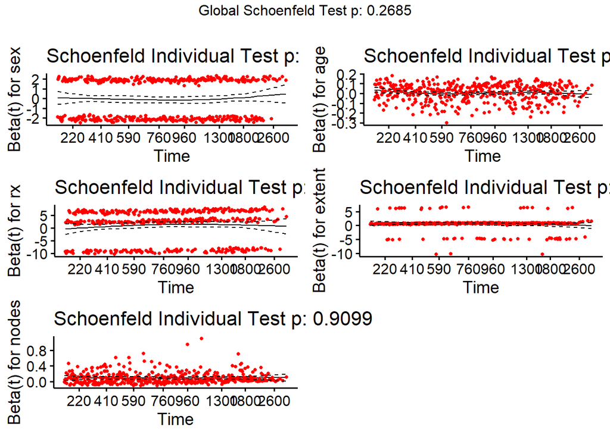

```r
ggcoxzph(cox_zph_test)
```

# 7. Modelos estratificados e interacciones

## Estratificación por sexo

```r
cox_strat <- coxph(Surv(time, status) ~ strata(sex) + age + rx + extent + nodes, data = colon_clean)
summary(cox_strat)
```

```
Call:
coxph(formula = Surv(time, status) ~ strata(sex) + age + rx +
    extent + nodes, data = colon_clean)

  n= 888, number of events= 430

               coef exp(coef)  se(coef)      z Pr(>|z|)
age        0.006235  1.006254  0.004121  1.513  0.13028
rxLev     -0.102693  0.902404  0.113604 -0.904  0.36602
rxLev+5FU -0.395365  0.673434  0.121570 -3.252  0.00115 **
extent     0.490102  1.632483  0.114375  4.285 1.83e-05 ***
nodes      0.089487  1.093613  0.009267  9.656  < 2e-16 ***
---
Signif. codes:  0 '***' 0.001 '**' 0.01 '*' 0.05 '.' 0.1 ' ' 1

          exp(coef) exp(-coef) lower .95 upper .95
age          1.0063     0.9938    0.9982    1.0144
rxLev        0.9024     1.1082    0.7223    1.1275
rxLev+5FU    0.6734     1.4849    0.5307    0.8546
extent       1.6325     0.6126    1.3046    2.0427
nodes        1.0936     0.9144    1.0739    1.1137

Concordance= 0.654  (se = 0.013 )
Likelihood ratio test= 103.4  on 5 df,   p=<2e-16
Wald test            = 128  on 5 df,   p=<2e-16
Score (logrank) test = 132  on 5 df,   p=<2e-16
```

**Interpretación del modelo de Cox**

Este modelo evalúa el efecto de varias variables clínicas sobre el riesgo de muerte en pacientes con cáncer de colon, estratificando por sexo.

| Variable | HR (exp(coef)) | p-valor | Interpretación |
| --- | --- | --- | --- |
| `age` | 1.006 | 0.13 | No significativa. Cada año de edad aumenta ligeramente el riesgo, pero no de forma significativa. |
| `rxLev` | 0.902 | 0.366 | No significativa. Tratamiento con leucovorina (Lev) no reduce el riesgo significativamente comparado con observación. |
| `rxLev+5FU` | 0.673 | 0.001 ** | Significativa. Tratamiento con Lev+5FU reduce el riesgo en un **32.7%** comparado con observación. |
| `extent` | 1.632 | <0.001*** | Muy significativa. A mayor extensión del tumor, mayor riesgo. |
| `nodes` | 1.094 | <0.001*** | Muy significativa. Cada ganglio afectado aumenta el riesgo en un **9.4%**. |

**Conclusión**: - El tratamiento `Lev+5FU` mejora significativamente la supervivencia. - `extent` y `nodes` son fuertes predictores del riesgo. - `age` y `rxLev` no muestran efectos significativos. - La estratificación por `sex` permite controlar diferencias de riesgo basal entre hombres y mujeres sin estimar coeficiente para `sex`.

Estadísticas globales: - Concordancia = 0.654 → modelo con poder predictivo moderado. - Tests de verosimilitud, Wald y log-rank altamente significativos (p < 0.001).